# Lab 2: Spatial Analysis and Visualization

Healthcare Access and Equity in Pennsylvania

Author

Jenny Brar

Published

May 23, 2026

## Assignment Overview

**Learning Objectives:** - Apply spatial operations to answer policy-relevant research questions - Integrate census demographic data with spatial analysis - Create publication-quality visualizations and maps - Work with spatial data from multiple sources - Communicate findings effectively for policy audiences

## Part 1: Healthcare Access for Vulnerable Populations

### Research Question

**Which Pennsylvania counties have the highest proportion of vulnerable populations (elderly + low-income) living far from hospitals?**

Your analysis should identify counties that should be priorities for healthcare investment and policy intervention.

### Required Analysis Steps

Complete the following analysis, documenting each step with code and brief explanations:

#### Step 1: Data Collection (5 points)

Load the required spatial data: - Pennsylvania county boundaries - Pennsylvania hospitals (from lecture data) - Pennsylvania census tracts

**Your Task:** #| message: false #| warning: false #| results: ‘hide’

```r
# Load required packages
library(sf)
library(tidyverse)
library(tidycensus)
library(tigris)
library(scales)
library(patchwork)
library(RColorBrewer)
library(here)


# Load spatial data
PA_county <- st_read(here("lab/lab_2/data/Pennsylvania_County_Boundaries.shp"))
districts <- st_read(here("lab/lab_2/data/districts.geojson"))
hospital <- st_read(here("lab/lab_2/data/hospitals.geojson"))
census_tracts <- tracts(state= "PA", cb= TRUE)

#UPDATE CRS

districts <- st_transform(districts, st_crs(PA_county))
hospital <- st_transform(hospital, st_crs(PA_county))
census_tracts <- st_transform(census_tracts, st_crs(PA_county))

# Check all CRS match:
st_crs(PA_county)
st_crs(districts)
st_crs(hospital)
st_crs(census_tracts)
```

**Questions to answer:** - How many hospitals are in your dataset? 223 - How many census tracts? 3445 - What coordinate reference system is each dataset in? All were changed to match the same CRS as PA_county, which, once confirmed using st_crs , is WGS 1984.

#### Step 2: Get Demographic Data

Use `tidycensus` to download tract-level demographic data for Pennsylvania.

**Required variables:** - Total population - Median household income - Population 65 years and over (you may need to sum multiple age categories)

**Your Task:**

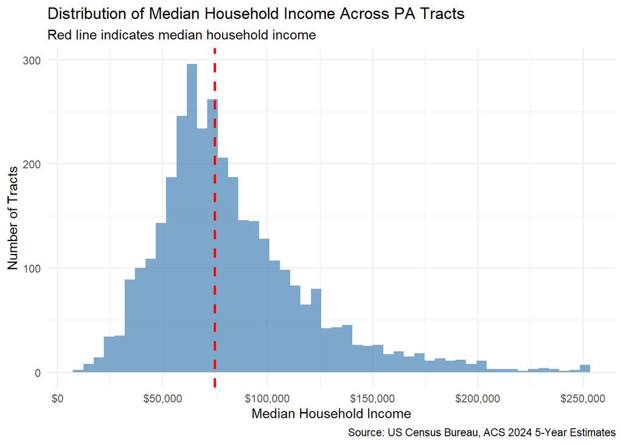

```r
# Get demographic (data from ACS

#list of all variables. Note. to ensure the most updated Data, I will be using ACS 2024 for this analysis.

acs24_vars <- load_variables(2024, "acs5", cache=TRUE)


#total population- filtered
Total_pop <- acs24_vars%>%
  filter(str_detect(concept, "Total Population"))

Total_pop <- "B01003_001"

#Median HH Income
Med_HH_Inc <- acs24_vars %>%
  filter(str_detect(concept, "Median Household Income"))

Med_HH_Inc <- "B19013_001"

#Data

PA_data <- get_acs(
  geography = "tract",
  state = "PA",
  variables = c(
    total_pop = "B01003_001",
    pop_65plus = "B01001_020",
    med_hh_inc = "B19013_001"
  ),
  year = 2024,
  survey = "acs5",
  output = "wide"
)

#UPDATE: Population 65+: Males 65+: B01001_020 to B01001_025. Females 65+: B01001_044 to B01001_049

PA_data <- get_acs(
  geography = "tract",
  state = "PA",
  variables = c(
    total_pop = "B01003_001",
    med_hh_inc = "B19013_001",
    male_65_66 = "B01001_020",
    male_67_69 = "B01001_021",
    male_70_74 = "B01001_022",
    male_75_79 = "B01001_023",
    male_80_84 = "B01001_024",
    male_85plus = "B01001_025",
    female_65_66 = "B01001_044",
    female_67_69 = "B01001_045",
    female_70_74 = "B01001_046",
    female_75_79 = "B01001_047",
    female_80_84 = "B01001_048",
    female_85plus = "B01001_049"
  ),
  year = 2024,
  survey = "acs5",
  output = "wide"
) %>%
#create a new column to combine the data tables for 65+
  mutate(
    pop_65plus = male_65_66E + male_67_69E + male_70_74E +
                 male_75_79E + male_80_84E + male_85plusE +
                 female_65_66E + female_67_69E + female_70_74E +
                 female_75_79E + female_80_84E + female_85plusE
  )


#Clean Tract Names
PA_data <- PA_data %>%
  mutate(Census_tract=str_remove(NAME, "Census Tract"),
         Census_tract = str_remove(Census_tract, "; Pennsylvania"))


#new column for County only..Multiple steps due to long string in NAME.
#Separate the text, then extract the part we want. From there remove the unwanted words. Easier than str_extract for this string:

PA_data <- PA_data %>%
  separate(NAME, into = c("Tract", "County", "State"), sep = ";") %>%
  mutate(
    County = str_trim(County),
    County = str_remove(County, " County")
  )


# Join to tract boundaries- I want to keep all the census tract geometries and add the PA data to it ->left join
tract_data <- census_tracts %>%
  left_join(PA_data, by = "GEOID")


#tracts with missing Income data

tract_data %>%
  filter(is.na(med_hh_incE)) %>%
  select(GEOID, NAME, med_hh_incE)


#Histogram of Median Household Income

ggplot(tract_data) +
  aes(x = med_hh_incE) +
  geom_histogram(bins = 50, fill = "steelblue", alpha = 0.7) +
  #Will produce the line at the median income
  geom_vline(xintercept = median(tract_data$med_hh_incE, na.rm = TRUE),
             color = "red", linetype = "dashed", linewidth = 1) +
  labs(
    title = "Distribution of Median Household Income Across PA Tracts",
    subtitle = "Red line indicates median household income",
    x = "Median Household Income",
    y = "Number of Tracts",
    caption = "Source: US Census Bureau, ACS 2024 5-Year Estimates"
  ) +
  theme_minimal() +
  scale_x_continuous(labels = dollar)
```

```r
#Median HH Income Across PA

median(tract_data$med_hh_incE, na.rm = TRUE)

#Median HH Income Summary. na.rm = remove the NA values...
summary_stats <- tract_data %>%
  summarize(
    min = min(med_hh_incE, na.rm = TRUE),
    max = max(med_hh_incE, na.rm = TRUE),
    mean = mean(med_hh_incE, na.rm = TRUE),
    median = median(med_hh_incE, na.rm = TRUE)
  )

library(knitr)
summary_stats %>%
  kable(caption = "Median Household Income Across PA Tracts",
        format.args = list(big.mark = ","),
        digits = 0)

summary_med_inc <- summary(tract_data$med_hh_incE)
```

[output not shown]

**Questions to answer:** - What year of ACS data are you using?

To ensure that I have the most up-to-date data, this analysis will reply on 2024 ACS data.

- How many tracts have missing income data?

There are 68 census tracts with missing income data.

- What is the median income across all PA census tracts?

The median household income is $74, 844.00. This is reflected as the red line on the histogram.

#### Step 3: Define Vulnerable Populations

Identify census tracts with vulnerable populations based on TWO criteria: 1. Low median household income (choose an appropriate threshold) 2. Significant elderly population (choose an appropriate threshold)

**Your Task:**

```r
# Filter for vulnerable tracts based on your criteria
#Create a new column for percent of population that is 65+
vulnerable_tracts <- tract_data %>%
  mutate(
    pct_65plus = round((pop_65plus / total_popE) * 100, 2),
    Inc_thresh = case_when(
      med_hh_incE <= 25820 ~ "low",
      med_hh_incE > 25820 & med_hh_incE <= 59605 ~ "low-moderate",
      med_hh_incE > 59605 & med_hh_incE <= 99295 ~ "moderate-high",
      med_hh_incE > 99295 ~ "high"
    ),
    pop_65_share = case_when(
      pct_65plus > 20 ~ "higher",
      pct_65plus == 20 ~ "same",
      pct_65plus < 20 ~ "lower"
    )
  ) %>%
  filter(
    med_hh_incE < 25820,
    pct_65plus >= 20
  )

# Percent of vulnerable census tracts relative to all of PA. 1. get number of rows first.

round(nrow(vulnerable_tracts) / nrow(tract_data) * 100, 2)
```

**Questions to answer:** - What income threshold did you choose and why?

To ensure more meaningful thresholds, the Federal “poverty” income threshold, alongside the actual median income from the 2024 ACS for Pennsylvania will be used. The federal poverty levels are determinined by household size, where a family of one is considered to meet the poverty level if they are making $15,060 and housholds of two are considered at the poverty level if their income is $20,440 [^1] and so on. Based on this the best course of action was to determine the average household size in Pennsylvania, which is between 2.4 to 2.48 [^2], which will be rounded up to three for sake of ease. Thereby, the income threshold for for “low” is $25,820. It is important to note that because not all household sizes are considered, this could impact the analysis.

Further, because Pennsylvania does not use the traditional income brackets (it applies a standard tax percent to all residents/non residents), it is not possible to make income thresholds based on tax brackets. However, based on the histogram, and the summary statistics, which shows a range in median incomes from just under $9,000.00 up to $250,000.00, and the “low” category designated as $ 25,820, the remaining categories are low-moderate, moderate-high, and high. There correspond to $25,820 to $59,605, $59,605 to $99,295,and above $99,295, respectively.

- What elderly population threshold did you choose and why?

Over 20% of Pennsylvania’s population is 65 or older [^3]. Therefore, tracts where the elderly population exceeds 20% were seen as having a disproportionately high elderly concentration relative to the the PA baseline, making them more likely to face healthcare access challenges.

- How many tracts meet your vulnerability criteria? There are 14 census tracts that are considered to have lower median household incomes, and higher shares of older adults, relative to the average for Pennsylvania.
- What percentage of PA census tracts are considered vulnerable by your definition?

```r
# Filter for vulnerable tracts based on your criteria
#Create a new column for percent of population that is 65+
vulnerable_tracts1 <- tract_data %>%
  mutate(
    pct_65plus = round((pop_65plus / total_popE) * 100, 2),
    Inc_thresh = case_when(
      med_hh_incE <= 25820 ~ "low",
      med_hh_incE > 25820 & med_hh_incE <= 59605 ~ "low-moderate",
      med_hh_incE > 59605 & med_hh_incE <= 99295 ~ "moderate-high",
      med_hh_incE > 99295 ~ "high"
    ),
    pop_65_share = case_when(
      pct_65plus > 15 ~ "higher",
      pct_65plus < 15 ~ "lower"
    )
  )


#Now, apply the new thresholds...

vulnerable_tracts2 <- vulnerable_tracts1 %>%
  filter(
    med_hh_incE <= 25820,
    pct_65plus >= 15
  )

# Percent of vulnerable census tracts relative to all of PA.

round(nrow(vulnerable_tracts2) / nrow(tract_data) * 100, 2)
```

## # Although it is still less than one percent, the total number of tracts did increase by about 10 from 14 to 24.

#### Step 4: Calculate Distance to Hospitals

For each vulnerable tract, calculate the distance to the nearest hospital.

**Your Task:**

```r
# Transform to appropriate projected CRS
# Because we will now be calculating the distance, we will have to change the projection to NAD 83 for PA (code used is 3364). This projection is used due to its popularity and my familiarity of it from GIS Spatial Modelling taken last semester.

vulnerable_tracts_proj <- vulnerable_tracts2 %>%
  st_transform(crs = 3364)

hospital_proj <- hospital %>%
  st_transform(crs = 3364)

#Create variable to get centroid of tracts
tract_centroids <- st_centroid(vulnerable_tracts_proj)

#Calculate distance to nearest hospital from tract_centroid
dist_hosp <- st_distance(tract_centroids, hospital_proj)

#minimum distance for each tract and converting ft to miles by dividing by 5280
vulnerable_tracts_proj <- vulnerable_tracts_proj %>%
  mutate(
    dist_nearest_hosp = apply(dist_hosp, 1, min),
    dist_miles = as.numeric(dist_nearest_hosp) / 5280
  )

#Summary Statistics

summary(vulnerable_tracts_proj$dist_miles)

#Vulnerable tracts more than 15 miles away from a hospital

vulnerable_tracts_proj_15 <- vulnerable_tracts_proj %>%
  filter (
    dist_miles >= 15
  )
```

[output not shown]

**Requirements:** - Use an appropriate projected coordinate system for Pennsylvania - Calculate distances in miles - Explain why you chose your projection

**Questions to answer:** - What is the average distance to the nearest hospital for vulnerable tracts?

For tracts identified as vulnerable (based on share of population 65 years and older, and income thresholds), the average distance is .33 miles.

- What is the maximum distance?

On the other hand, the largest distance is just over a mile, at 1.28 miles to the nearest hospital.

- How many vulnerable tracts are more than 15 miles from the nearest hospital?

Although it is quite likely that “non-vulnerable” tracts can be 15 or more miles away from the nearest hospital, in this data set there are none.

#### Step 5: Identify Underserved Areas

Define “underserved” as vulnerable tracts that are more than 15 miles from the nearest hospital.

**Your Task:**

```r
# Create under-served variable
vulnerable_tracts_proj <- vulnerable_tracts_proj %>%
  mutate(
    underserved = ifelse(dist_miles >= 15, "Yes", "No")
  )

# How many tracts are under-served?
sum(vulnerable_tracts_proj$underserved == "Yes")

# % of vulnerable tracts that are under-served. Rounding numbers to nearest two digits
round(sum(vulnerable_tracts_proj$underserved == "Yes") / nrow(vulnerable_tracts_proj) * 100, 2)
```

**Questions to answer:** - How many tracts are underserved? - What percentage of vulnerable tracts are underserved? - Does this surprise you? Why or why not?

Interestingly, there are no vulnerable tracts that are 15 or more miles away from hospitals. While this is seemingly good news, at a more granular level, where we may look at racial groups or even sex and gender, this finding may very well be different. At the same time, the current findings could be a reflection of, possibly, the vulnerability criteria used here (very low income plus high elderly population share) tends to identify tracts in more urbanized areas (higher populations) where hospital access is generally better. Through this analysis, it is clear that distance on its own may not be the only barrier to healthcare access, and future analyses should consider additional barriers such as transportation access or if hospitals (within a certain distance) accept Medicaid patients.

#### Step 6: Aggregate to County Level

Use spatial joins and aggregation to calculate county-level statistics about vulnerable populations and hospital access.

**Your Task:**

```r
# Spatial join tracts to counties
# Aggregate statistics by county
# Match projection for distance calculations
PA_county_proj <- PA_county %>%
  st_transform(crs = 3364)

# Spatial join tracts abd county. Bring over county name only
tracts_county <- vulnerable_tracts_proj %>%
  st_join(PA_county_proj %>% select(COUNTY_NAM))


#Aggregate stats by county, create summaries, then arrange in order of distance.
#Note updated table already has vulnerable populations (low income seniors), making it the total population for that data set.

county_summary <- tracts_county %>%
  st_drop_geometry() %>%
  group_by(COUNTY_NAM) %>%
  summarize(
    num_vulnerable_tracts = n(), #to get the count
    num_underserved_tracts = sum(underserved == "Yes", na.rm = TRUE), #only looking at total under-served, not including NA values
    pct_underserved = round(num_underserved_tracts / num_vulnerable_tracts * 100, 2),
    avg_dist_miles = round(mean(dist_miles, na.rm = TRUE), 2),
    total_vulnerable_pop = sum(pop_65plus, na.rm = TRUE) #population in this data set, that was joined with PA counties, already only included population 65+ with low incomes.
  ) %>%
  arrange(desc(avg_dist_miles)) #order from largest to smallest distances


# View results

county_summary %>%
  kable(caption = "Health Care Access by Vulnerable Tracts per County in PA",
        format.args = list(big.mark = ","),
        col.names = c("County", "Vulnerable Tracts", "Underserved Tracts", "% Underserved", "Avg Distance (miles)", "Low Income Seniors"),
        digits = 0)
```

[output not shown]

**Required county-level statistics:** - Number of vulnerable tracts - Number of underserved tracts  
- Percentage of vulnerable tracts that are underserved - Average distance to nearest hospital for vulnerable tracts - Total vulnerable population

**Questions to answer:** - Which 5 counties have the highest percentage of underserved vulnerable tracts? - Which counties have the most vulnerable people living far from hospitals? - Are there any patterns in where underserved counties are located?

#### Step 7: Create Summary Table

Create a professional table showing the top 10 priority counties for healthcare investment.

**Your Task:**

```r
# Create and format priority counties table by number of lower income seniors and # of tracts

county_priority <- county_summary %>%
  st_drop_geometry() %>%
  group_by(COUNTY_NAM) %>%
  summarize(
    vulnerable_tracts = sum(num_vulnerable_tracts, na.rm= TRUE),
    pop_impacted = sum(total_vulnerable_pop, na.rm = TRUE)
  ) %>%
  arrange(desc(pop_impacted)) %>%
  mutate(priority_rank = row_number())

county_priority %>%
  kable(
    caption = "County Priority Ranking Based on Vulnerable Tracts and Population Impacted",
    col.names = c("County", "Vulnerable Tracts", "Population Impacted", "Priority Rank"),
    format.args = list(big.mark = ","),
    digits = 0
  )
```

[output not shown]

**Requirements:** - Use `knitr::kable()` or similar for formatting - Include descriptive column names - Format numbers appropriately (commas for population, percentages, etc.) - Add an informative caption - Sort by priority (you decide the metric)

## Part 2: Comprehensive Visualization

Using the skills from Week 3 (Data Visualization), create publication-quality maps and charts.

### Map 1: County-Level Choropleth

Create a choropleth map showing healthcare access challenges at the county level.

**Your Task:**

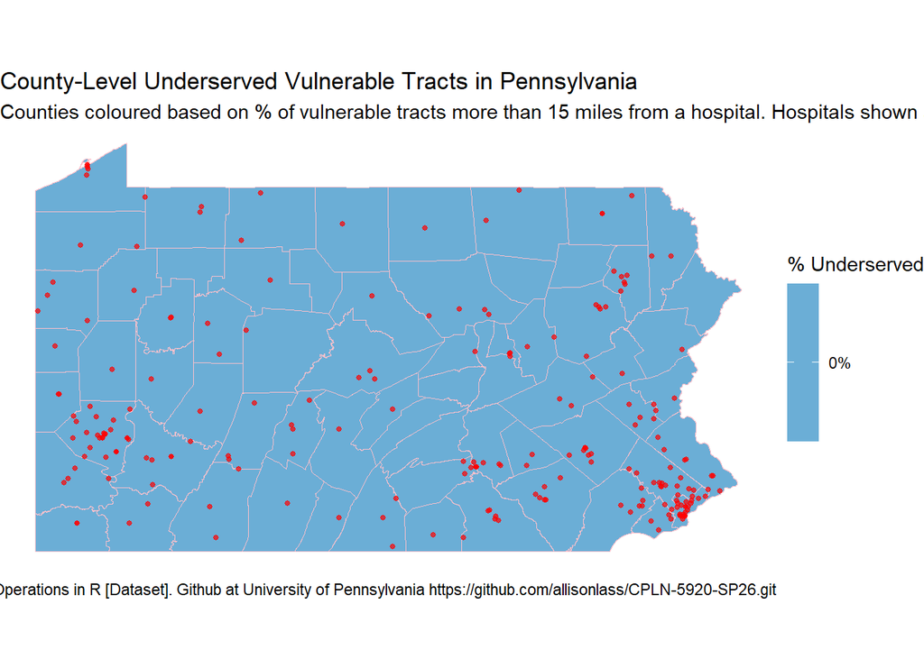

```r
# Create county-level access map- This one will be one colour per the data above. ***However, there is another choropleth map to show the distribution of higher shares of seniors with lower incomes per tract.

priority_map <- PA_county %>%
  left_join(county_summary, by = "COUNTY_NAM") %>%
  mutate(
    vulnerable_tracts = replace_na(num_vulnerable_tracts, 0),
    underserved_tracts = replace_na(num_underserved_tracts, 0),
    pct_underserved = replace_na(pct_underserved, 0),
    avg_dist_miles = replace_na(avg_dist_miles, 0),
    total_vulnerable_pop = replace_na(total_vulnerable_pop, 0)
  )
#Map 1
ggplot(priority_map) +
  geom_sf(aes(fill = pct_underserved), color = "pink", linewidth = 0.2) +
  geom_sf(data = hospital, color = "red", alpha = 0.7, size = 1) +
  scale_fill_distiller(
    palette = "Blues",
    direction = 1,
    labels = function(x) paste0(x, "%"),
    name = "% Underserved"
  ) +
  labs(
    title = "County-Level Underserved Vulnerable Tracts in Pennsylvania",
    subtitle = "Counties coloured based on % of vulnerable tracts more than 15 miles from a hospital. Hospitals shown as red points",
    caption = "Source: US Census Bureau, ACS 2024 5-Year Estimates; Lassiter, A. (2026). Week 4:Spatial Data & GIS Operations in R [Dataset]. Github at University of Pennsylvania https://github.com/allisonlass/CPLN-5920-SP26.git"
  ) +
  theme_void()
```

```r
#Additonal Map using percent of population 65+ and low incomes as the model.

priority_map1 <- priority_map %>%
  mutate(
    # vulnerable_tracts has no NA's
    vulnerable_tracts = replace_na(vulnerable_tracts, 0),

    # create bins based on number of vulnerable tracts
    vuln_bin = case_when(
      vulnerable_tracts <= 1 ~ "0–1",
      vulnerable_tracts <= 3 ~ "2–3",
      TRUE ~ "4+"
    ),

    # 3)Acknowledgement: Used Ai for factor function. This is to make sure that the bins are in the correct order once mapped.
    vuln_bin = factor(vuln_bin, levels = c("0–1", "2–3", "4+"))
  )
# Plotting the new map:
vulnerable_tractsmap <- ggplot(priority_map1) +
  geom_sf(aes(fill = vuln_bin), color = "pink", linewidth = 0.2) +
  geom_sf(data = hospital, color = "red", alpha = 0.7, size = 1) +
  scale_fill_brewer(
    palette = "Blues",
    name = "Vulnerable tracts per county" # this is the legend name
  ) +
  labs(
    title = "Number of Vulnerable Tracts per County in Pennsylvania",
    subtitle = "Counties categorized by number of vulnerable tracts (0–1, 2–3, 4+). Hospitals represented as red points.",
    caption = "Source: US Census Bureau, ACS 2024 5-Year Estimates; Lassiter, A. (2026). Week 4:Spatial Data & GIS Operations in R [Dataset]. Github at University of Pennsylvania https://github.com/allisonlass/CPLN-5920-SP26.git"
  ) +
  theme_void() #removes background and other unnecessary details to make map look professional
```

[output not shown]

**Requirements:** - Fill counties by percentage of vulnerable tracts that are underserved - Include hospital locations as points - Use an appropriate color scheme - Include clear title, subtitle, and caption - Use `theme_void()` or similar clean theme - Add a legend with formatted labels

### Map 2: Detailed Vulnerability Map

Create a map highlighting underserved vulnerable tracts.

**Your Task:**

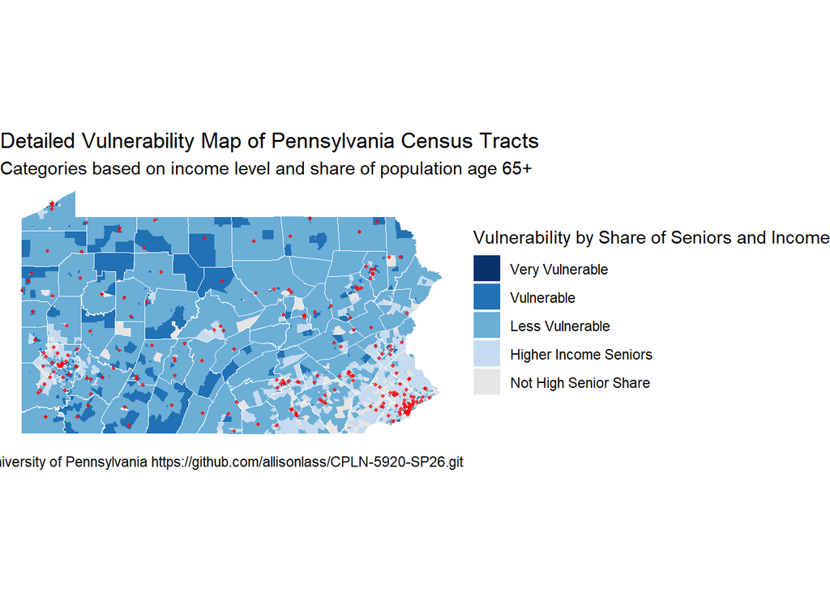

```r
# Create detailed tract-level map
#We want to should the variation among census tracts, with the county boarders present to help visualize what areas may need more investment. To allow for better visualization, I will use the same concept as the above map, and refrain from "under-served" due to a lack of numbers.

#creating new categories to map by tract
tracts_map <- vulnerable_tracts1 %>%
  mutate(
    vulnerability = case_when(
      med_hh_incE <= 25820 & pct_65plus >= 15 ~ "Very Vulnerable",
      med_hh_incE < 59605 & pct_65plus >= 15 ~ "Vulnerable",
      med_hh_incE < 99295 & pct_65plus >= 15 ~ "Less Vulnerable",
      med_hh_incE >= 99295 & pct_65plus >= 15 ~ "Higher Income Seniors", #not vulnerable was orgiinally used, but could be seen as a problematic term, so it was changed to high income seniors.
      TRUE ~ "Not High Senior Share"
    ),
    vulnerability = factor(
      vulnerability,
      levels = c(
        "Very Vulnerable",
        "Vulnerable",
        "Less Vulnerable",
        "Higher Income Seniors",
        "Not High Senior Share"
      )
    )
  )

#Plotting the map. Note. code to create variation in colours and colour codes from Claude AI

ggplot() +
  geom_sf(data = tracts_map, aes(fill = vulnerability), color = NA) +
  geom_sf(data = PA_county, fill = NA, color = "white", linewidth = 0.2) +
  geom_sf(data = hospital, color = "red", size = 0.8, alpha = 0.7) +
  scale_fill_manual(
    values = c(
      "Very Vulnerable" = "#08306b",
      "Vulnerable" = "#2171b5",
      "Less Vulnerable" = "#6baed6",
      "Higher Income Seniors" = "#c6dbef",
      "Not High Senior Share" = "grey90"
    ),
    name = "Vulnerability by Share of Seniors and Income"
  ) +
  labs(
    title = "Detailed Vulnerability Map of Pennsylvania Census Tracts",
    subtitle = "Categories based on income level and share of population age 65+",
    caption = "Source: US Census Bureau, ACS 2024 5-Year Estimates; Lassiter, A. (2026). Week 4:Spatial Data & GIS Operations in R [Dataset]. Github at University of Pennsylvania https://github.com/allisonlass/CPLN-5920-SP26.git"
  ) +
  theme_void()
```

**Requirements:** - Show underserved vulnerable tracts in a contrasting color - Include county boundaries for context - Show hospital locations - Use appropriate visual hierarchy (what should stand out?) - Include informative title and subtitle

### Chart: Distribution Analysis

Create a visualization showing the distribution of distances to hospitals for vulnerable populations.

**Your Task:**

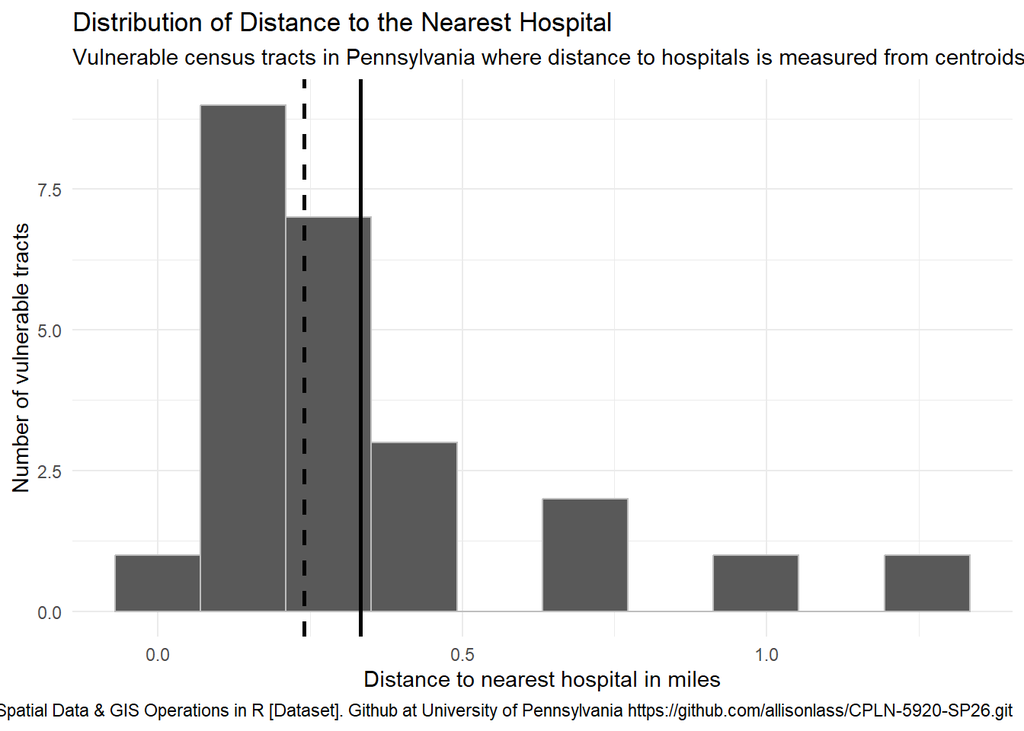

```r
# Create distribution visualization

# Histogram of distance to nearest hospital for vulnerable tracts
ggplot(vulnerable_tracts_proj) +
  aes(x = dist_miles) +
  geom_histogram(bins = 10, color = "grey") +
  geom_vline(
    xintercept = median(vulnerable_tracts_proj$dist_miles, na.rm = TRUE),
    linetype = "dashed",
    linewidth = 1
  ) +
  geom_vline( #this is to highlight the average distance on the chart using a regular line- median uses dashed like for distinction.
    xintercept = mean(vulnerable_tracts_proj$dist_miles, na.rm = TRUE),
    linewidth = 1
  ) +
  scale_x_continuous(labels = comma) +
  labs(
    title = "Distribution of Distance to the Nearest Hospital",
    subtitle = "Vulnerable census tracts in Pennsylvania where distance to hospitals is measured from centroids",
    x = "Distance to nearest hospital in miles",
    y = "Number of vulnerable tracts",
    caption =  "Source: US Census Bureau, ACS 2024 5-Year Estimates; Lassiter, A. (2026). Week 4:Spatial Data & GIS Operations in R [Dataset]. Github at University of Pennsylvania https://github.com/allisonlass/CPLN-5920-SP26.git"
  ) +
  theme_minimal()
```

**Suggested chart types:** - Histogram or density plot of distances - Box plot comparing distances across regions - Bar chart of underserved tracts by county - Scatter plot of distance vs. vulnerable population size

**Requirements:** - Clear axes labels with units - Appropriate title - Professional formatting - Brief interpretation (1-2 sentences as a caption or in text)

## Part 3: Bring Your Own Data Analysis

Choose your own additional spatial dataset and conduct a supplementary analysis.

### Challenge Options

Choose ONE of the following challenge exercises, or propose your own research question using OpenDataPhilly data (https://opendataphilly.org/datasets/).

**Note these are just loose suggestions to spark ideas - follow or make your own as the data permits and as your ideas evolve. This analysis should include bringing in your own dataset, ensuring the projection/CRS of your layers align and are appropriate for the analysis (not lat/long or geodetic coordinate systems). The analysis portion should include some combination of spatial and attribute operations to answer a relatively straightforward question**

#### Education & Youth Services

**Option A: Educational Desert Analysis** - **Data:** Schools, Libraries, Recreation Centers, Census tracts (child population) - **Question:** “Which neighborhoods lack adequate educational infrastructure for children?” - **Operations:** Buffer schools/libraries (0.5 mile walking distance), identify coverage gaps, overlay with child population density - **Policy relevance:** School district planning, library placement, after-school program siting

**Option B: School Safety Zones** - **Data:** Schools, Crime Incidents, Bike Network - **Question:** “Are school zones safe for walking/biking, or are they crime hotspots?” - **Operations:** Buffer schools (1000ft safety zone), spatial join with crime incidents, assess bike infrastructure coverage - **Policy relevance:** Safe Routes to School programs, crossing guard placement

#### Environmental Justice

**Option C: Green Space Equity** - **Data:** Parks, Street Trees, Census tracts (race/income demographics) - **Question:** “Do low-income and minority neighborhoods have equitable access to green space?” - **Operations:** Buffer parks (10-minute walk = 0.5 mile), calculate tree canopy or park acreage per capita, compare by demographics - **Policy relevance:** Climate resilience, environmental justice, urban forestry investment —

#### Public Safety & Justice

**Option D: Crime & Community Resources** - **Data:** Crime Incidents, Recreation Centers, Libraries, Street Lights - **Question:** “Are high-crime areas underserved by community resources?” - **Operations:** Aggregate crime counts to census tracts or neighborhoods, count community resources per area, spatial correlation analysis - **Policy relevance:** Community investment, violence prevention strategies —

#### Infrastructure & Services

**Option E: Polling Place Accessibility** - **Data:** Polling Places, SEPTA stops, Census tracts (elderly population, disability rates) - **Question:** “Are polling places accessible for elderly and disabled voters?” - **Operations:** Buffer polling places and transit stops, identify vulnerable populations, find areas lacking access - **Policy relevance:** Voting rights, election infrastructure, ADA compliance

#### Health & Wellness

**Option F: Recreation & Population Health** - **Data:** Recreation Centers, Playgrounds, Parks, Census tracts (demographics) - **Question:** “Is lack of recreation access associated with vulnerable populations?” - **Operations:** Calculate recreation facilities per capita by neighborhood, buffer facilities for walking access, overlay with demographic indicators - **Policy relevance:** Public health investment, recreation programming, obesity prevention

#### Emergency Services

**Option G: EMS Response Coverage** - **Data:** Fire Stations, EMS stations, Population density, High-rise buildings - **Question:** “Are population-dense areas adequately covered by emergency services?” - **Operations:** Create service area buffers (5-minute drive = ~2 miles), assess population coverage, identify gaps in high-density areas - **Policy relevance:** Emergency preparedness, station siting decisions

#### Arts & Culture

**Option H: Cultural Asset Distribution** - **Data:** Public Art, Museums, Historic sites/markers, Neighborhoods - **Question:** “Do all neighborhoods have equitable access to cultural amenities?” - **Operations:** Count cultural assets per neighborhood, normalize by population, compare distribution across demographic groups - **Policy relevance:** Cultural equity, tourism, quality of life, neighborhood identity

### Data Sources

**OpenDataPhilly:** https://opendataphilly.org/datasets/ - Most datasets available as GeoJSON, Shapefile, or CSV with coordinates - Always check the Metadata for a data dictionary of the fields.

**Additional Sources:** - **Pennsylvania Open Data:** https://data.pa.gov/ - **Census Bureau (via tidycensus):** Demographics, economic indicators, commute patterns - **TIGER/Line (via tigris):** Geographic boundaries

### Recommended Starting Points

**If you’re feeling confident:** Choose an advanced challenge with multiple data layers. **If you are a beginner, choose something more manageable that helps you understand the basics**

**If you have a different idea:** Propose your own question! Just make sure: - You can access the spatial data - You can perform at least 2 spatial operations

### Your Analysis

**Your Task:**

1. **Find and load additional data**
   - Document your data source
   - Check and standardize the CRS
   - Provide basic summary statistics

```r
# Load your additional dataset

# Load spatial data. Added one to prevent over-riding previous data sets.
PA_county1 <- st_read(here("lab/lab_2/data/Pennsylvania_County_Boundaries.shp"))
districts1 <- st_read(here("lab/lab_2/data/districts.geojson"))
hospital1 <- st_read(here("lab/lab_2/data/hospitals.geojson"))
recreation_PPR_sites1 <- st_read(here("lab/lab_2/data/PPR_Program_Sites.shp"))
census_tracts1 <- tracts(state= "PA", cb= TRUE)

#UPDATE CRS

districts1 <- st_transform(districts1, st_crs(PA_county1))
hospital1 <- st_transform(hospital1, st_crs(PA_county1))
census_tracts1 <- st_transform(census_tracts1, st_crs(PA_county1))
recreation_PPR_sites1 <- st_transform(recreation_PPR_sites1, st_crs(PA_county1))

# Check all CRS match:
st_crs(PA_county1)
st_crs(districts1)
st_crs(hospital1)
st_crs(census_tracts1)
st_crs(recreation_PPR_sites1)
```

**Questions to answer:** - What dataset did you choose and why? - What is the data source and date? - How many features does it contain? - What CRS is it in? Did you need to transform it?

2. **Pose a research question**

Write a clear research statement that your analysis will answer.

**Examples:** - “Do vulnerable tracts have adequate public transit access to hospitals?” - “Are EMS stations appropriately located near vulnerable populations?” - “Do areas with low vehicle access have worse hospital access?”

3. **Conduct spatial analysis**

Use at least TWO spatial operations to answer your research question.

**Required operations (choose 2+):** - Buffers - Spatial joins - Spatial filtering with predicates - Distance calculations - Intersections or unions - Point-in-polygon aggregation

Note. To make it easier for the data analyst, new code chunks were made for each step

**Your Task:**

```r
# Your spatial analysis

#The first step is to narrow our data to include only Philadelphia:
#Narrowing the data to only consider Philadelphia:
phl_boundary <- PA_county1 %>%
  filter(COUNTY_NAM == "PHILADELPHIA")

#Focusing on tracts only in Philadelphia by filtering the all PA census tracts.
phl_tracts <- census_tracts1 %>%
  st_filter(phl_boundary) #this will automatically use the predicate intersect

#Intersect was not suitable for this since it also ended up including some that slightly over lapped, so we'll switch to within:
phl_tracts <- census_tracts1 %>%
  st_filter(phl_boundary, .predicate = st_within)
```

```r
#The second thing we have to do is the join the data:

#Join with demographic Data from earlier. This will keep all our Philadelphia Census tracts, and only keep relevant/corresponding demographics
phl_tracts_data <- phl_tracts %>%
  left_join(PA_data, by = "GEOID")
```

```r
#Now, we're creating our index/categories (using the indicators from above)

phl_tracts_data <- phl_tracts_data %>%
  mutate(
    pct_65plus = round((pop_65plus / total_popE) * 100, 2),
    vulnerability = case_when(
      med_hh_incE <= 25820 & pct_65plus >= 15 ~ "Very Vulnerable",
      med_hh_incE > 25820 & med_hh_incE <= 59605 & pct_65plus >= 15 ~ "Vulnerable",
      med_hh_incE > 59605 & med_hh_incE <= 99295 & pct_65plus >= 15 ~ "Less Vulnerable",
      med_hh_incE > 99295 & pct_65plus >= 15 ~ "Higher Income Seniors",
      TRUE ~ "Below 15% Seniors" # Used from AI to make sure that the conditions I made above, if not met, will still assign a label to it.
    )
  )
```

```r
#Before we can create buffers around the sites, we need to convert crs.
phl_tracts_proj <- st_transform(phl_tracts_data, 3365) #this will use ft, so in the next operation we will have to convert our miles buffer to ft
recreation_proj <- st_transform(recreation_PPR_sites1, 3365)

#Now, we can create the buffers. We want to see a .5 mile buffer, which is 2640 ft.
rec_buffer <- st_buffer(recreation_proj, dist = 2640)
```

Note. half a mile was selected as, according an article, this is a reasonable walking distance for older adults, especially when considering that there main mode of transportation could be walking, this is especially important to consider when we look at the income thresholds [^5]

```r
#Now that we have the buffers, we want to see which census tracts are vulnerable.

access_PPR <- st_intersects(phl_tracts_proj, rec_buffer) #intersect here will give me a list of the tracts that intersect with the buffers we made above.
phl_tracts_proj <- phl_tracts_proj %>%
  mutate(
    rec_access = ifelse(lengths(access_PPR) > 0, "Within 0.5 miles", "No nearby site")
  ) #this will tell us if TRUE,m the tract intersects with at least one recreation buffer, and if FALSE, the tract intersects none.
```

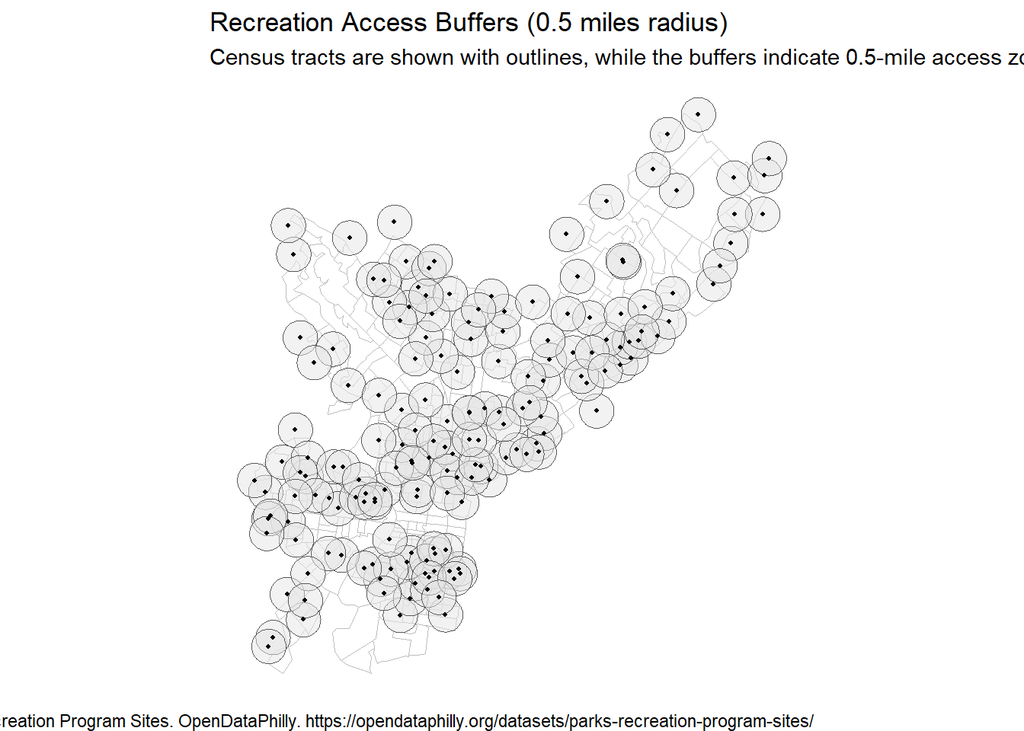

```r
#Quick visualization to see how the different layers look so far:

ggplot() +
  geom_sf(data = phl_tracts_proj, fill = NA, linewidth = 0.15, color = "grey") +#the first layer are the tracts, we just want an outline of it.
  geom_sf(data = rec_buffer, alpha = 0.5, linewidth = 0.1) +
   # the nextg layer are the buffers, and to make the map more readable, it will be somewhat transparent, relfected through the code "alpha".
  geom_sf(data = recreation_proj, size = 0.8) +
    #now we can show the PPR sites on top of this, which will  be points.
  #the below section is for the additional data on the table
  labs(
    title = "Recreation Access Buffers (0.5 miles radius)",
    subtitle = "Census tracts are shown with outlines, while the buffers indicate 0.5-mile access zones around PPR sites",
    caption = "Source: US Census Bureau, ACS 2024 5-Year Estimates; Lassiter, A. (2026). Week 4:Spatial Data & GIS Operations in R [Dataset]. Github at University of Pennsylvania https://github.com/allisonlass/CPLN-5920-SP26.git; Open Data Philly. (n.d.). Parks & Recreation Program Sites. OpenDataPhilly. https://opendataphilly.org/datasets/parks-recreation-program-sites/"
  ) +
  theme_void()
```

```r
#The above map shows the buffers around the recreation sites, but to get a better idea of who has better access to these sites, when considering tracts with higher senior populations and lower incomes, the below graphic does a better job

#First we want to find the distance to these sites:
#The goal here is to assign a distance vriable to each tract, which has already been classified as some level of vulnerability based on share of senior population and income.

tract_centroids1 <- st_centroid(phl_tracts_proj)
dist <- st_distance(tract_centroids1, recreation_proj) #distance from center of tract to rec site.
phl_tracts_proj <- phl_tracts_proj %>%
  mutate(
    nearest_rec_ft = apply(dist, 1, min), #this creates a new column where distance and finds the smallest distance/min distance
    nearest_rec_miles = as.numeric(nearest_rec_ft) / 5280 #for conversion
  )

# Clarifying what is considered vulnerable based on the distance

phl_tracts_proj <- phl_tracts_proj %>%
  mutate(
    high_risk = ifelse(
      vulnerability == "Very Vulnerable" & nearest_rec_miles > 0.5,
      "High Risk",
      "Other"
    )
  )
```

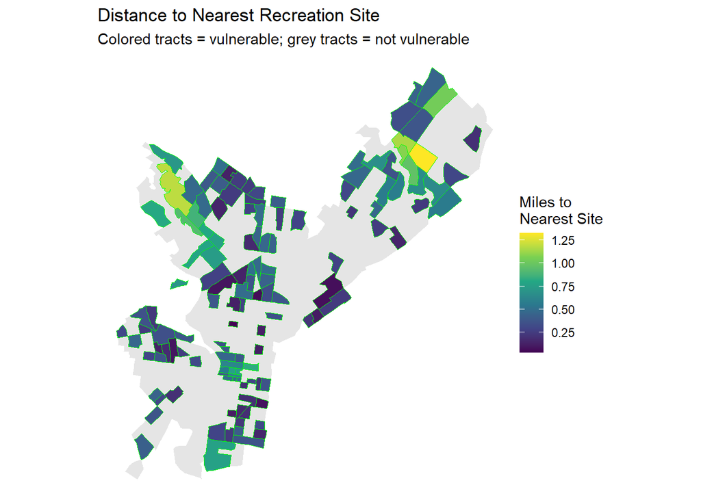

```r
#Now we're can map the vulberabilty based on senior population, median income, and distance to rec centers Putting it together:

phl_plot <- phl_tracts_proj %>%
  mutate(
    yes_vulnerable = vulnerability %in% c("Very Vulnerable", "Vulnerable", "Less Vulnerable", "Higher Income Seniors"),
    dist_plot = ifelse(yes_vulnerable, nearest_rec_miles, NA_real_)
  )

ggplot(phl_plot) +
  geom_sf(aes(fill = dist_plot), color = NA) +
  geom_sf(
    data = phl_plot %>% filter(yes_vulnerable),
    fill = NA, linewidth = 0.35, color = "green"
  ) +
  scale_fill_viridis_c( #this code will give different colours based on the distance.
    name = "Miles to\nNearest Site", #the \n is to put the rest of the text on the next line.
    na.value = "grey90"
  ) +
  labs(
    title = "Distance to Nearest Recreation Site",
    subtitle = "Colored tracts = vulnerable; grey tracts = not vulnerable"
  ) +
  theme_void()
```

```r
#Note. I would like to reverse the colours, but for now, this map is a better reflection of the access issues

#Additional information:

phl_tracts_proj %>%
  st_drop_geometry() %>%
  group_by(vulnerability) %>%
  summarize(mean_distance = mean(nearest_rec_miles, na.rm = TRUE))

phl_tracts_proj %>%
  kable(caption = "Distance to nearest Rec centers in Vulnerable Tracts",
        format.args = list(big.mark = ","),
        digits = 0)
```

[output not shown]

**Analysis requirements:** - Clear code comments explaining each step - Appropriate CRS transformations - Summary statistics or counts - At least one map showing your findings - Brief interpretation of results (3-5 sentences)

## Finally - A few comments about your incorporation of feedback!

The fist lab was not uploaded successfully. As a result, I deleted my existing portfolio, created a new one completed labs 0 and 1 again, and ensured that the website was working. Because I was not able to get specific feedback earlier, I applied code suggestions made in course announcements to make the final output look cleaner. I also added notes where i needed actual code help from AI beyond using it for interpretation/ explanations (acknowledgements below).

##Self Reflection

Moving forward, for future labs, I will need to be better organized with the data and follow the worflows from class. Specifically, keeping data sets clean after joining multiple ones and being able to understand what’s going on even before coding graphs, which, in this lab, have helped me understand what the outcomes of the operations I’ve done are. Additionally, I have printed each weeks codes to write my own notes on top to help conceptualize the technical aspects, as well as some policy-specific considerations.

Sources:

Lassiter, A. (2025). CPLN-5920-SP26: Course materials for CPLN 5920-MUSA 5080 Public Policy Analytics. GitHub; University of Pennsylvania. https://github.com/allisonlass/CPLN-5920-SP26.git LIHEAP ClearingHouse. (2024). Federal Poverty Guidelines for FFY 2025 . Acf.gov. https://liheapch.acf.gov/profiles/povertytables/FY2025/popstate.htm Open Data Philly. (n.d.). Parks & Recreation Program Sites. OpenDataPhilly. https://opendataphilly.org/datasets/parks-recreation-program-sites/ US Census Bureau. (2025a). QuickFacts: Pennsylvania. Census Bureau QuickFacts; United States Census Bureau. https://www.census.gov/quickfacts/fact/table/PA/PST045225US Census Bureau. (2025b, June 26). Older Adults Outnumber Children in 11 States and Nearly Half of U.S. Counties. Census.gov. https://www.census.gov/newsroom/press-releases/2025/older-adults-outnumber-children.html Watson, K. B., Carlson, S. A., Humbert-Rico, T., Carroll, D. D., & Fulton, J. E. (2015). Walking for Transportation: What Do U.S. Adults Think Is a Reasonable Distance and Time? Journal of Physical Activity and Health, 12(s1), S53–S61. https://doi.org/10.1123/jpah.2014-0062

## Submission Requirements

**What to submit:**

1. **Rendered HTML document posted to your course portfolio** with all code, outputs, maps, and text
   - Use `embed-resources: true` in YAML so it’s a single file
   - All code should run without errors
   - All maps and charts should display correctly
2. Submit the correct and working links of your assignment on Canvas

## Footnotes

[^1]: LIHEAP ClearingHouse. (2024). Federal Poverty Guidelines for FFY 2025 . Acf.gov. https://liheapch.acf.gov/profiles/povertytables/FY2025/popstate.htm
[^2]: US Census Bureau. (2025). QuickFacts: Pennsylvania. Census Bureau QuickFacts; United States Census Bureau. https://www.census.gov/quickfacts/fact/table/PA/PST045225
[^3]: US Census Bureau. (2025). QuickFacts: Pennsylvania. Census Bureau QuickFacts; United States Census Bureau. https://www.census.gov/quickfacts/fact/table/PA/PST045225
[^4]: US Census Bureau. (2025b, June 26). Older Adults Outnumber Children in 11 States and Nearly Half of U.S. Counties. Census.gov. https://www.census.gov/newsroom/press-releases/2025/older-adults-outnumber-children.html
[^5]: Watson, K. B., Carlson, S. A., Humbert-Rico, T., Carroll, D. D., & Fulton, J. E. (2015). Walking for Transportation: What Do U.S. Adults Think Is a Reasonable Distance and Time? Journal of Physical Activity and Health, 12(s1), S53–S61. https://doi.org/10.1123/jpah.2014-0062